# Lab 5 - Real data sets: LHC

##### PHYS434 - Advanced Laboratory: Computational Data Analysis

##### Professor: Miguel Morales

##### Due date: 11/15/2021

##### By Erik Solhaug

```python
%matplotlib inline
import numpy as np
import matplotlib
import matplotlib.pyplot as plt
import scipy
from scipy import stats
import h5py
import pickle
import math

import pandas as pd

#this sets the size of the plot to something useful
plt.rcParams["figure.figsize"] = (20,15)
```

```python
user_dir = '/home/jovyan/Phys434_Autumn2021/'
data_dir = user_dir + 'LHC_data/'
data_dir
```

```
'/home/jovyan/Phys434_Autumn2021/LHC_data/'
```

```python
with open(f'{data_dir}/higgs_100000_pt_250_500.pkl', 'rb') as f:
    higgs = pickle.load(f)
```

```python
with open(f'{data_dir}/qcd_100000_pt_250_500.pkl', 'rb') as f:
    qcd = pickle.load(f)
```

```python
higgs
```

|  | pt | eta | phi | mass | ee2 | ee3 | d2 | angularity | t1 | t2 | t3 | t21 | t32 | KtDeltaR |
| --- | --- | --- | --- | --- | --- | --- | --- | --- | --- | --- | --- | --- | --- | --- |
| 0 | 472.074292 | 0.137052 | -2.535145 | 125.150365 | 0.126581 | 0.002633 | 1.298020 | 0.008218 | 0.739787 | 0.283689 | 0.174944 | 0.383474 | 0.616674 | 0.557407 |
| 1 | 470.405678 | -0.039157 | 0.069669 | 130.552672 | 0.118071 | 0.002379 | 1.445626 | 0.013822 | 0.747927 | 0.234281 | 0.193354 | 0.313240 | 0.825308 | 0.704650 |
| 2 | 438.008357 | -0.181139 | -3.031083 | 125.703063 | 0.167344 | 0.004623 | 0.986597 | 0.004545 | 1.001379 | 0.440523 | 0.218649 | 0.439917 | 0.496338 | 0.487496 |
| 3 | 484.860421 | 0.251986 | 2.855706 | 126.215853 | 0.119238 | 0.002066 | 1.218467 | 0.006740 | 0.761892 | 0.228160 | 0.193810 | 0.299465 | 0.849449 | 0.594872 |
| 4 | 486.141137 | -1.917812 | -2.221953 | 132.182504 | 0.103632 | 0.001438 | 1.291784 | 0.000398 | 0.722656 | 0.166851 | 0.148080 | 0.230886 | 0.887497 | 0.678118 |
| ... | ... | ... | ... | ... | ... | ... | ... | ... | ... | ... | ... | ... | ... | ... |
| 99995 | 478.658254 | -0.837586 | -2.609921 | 125.707302 | 0.138041 | 0.001494 | 0.567994 | 0.000953 | 1.192189 | 0.131294 | 0.109689 | 0.110129 | 0.835446 | 0.504678 |
| 99996 | 465.171259 | 0.429341 | -1.446681 | 129.749906 | 0.135890 | 0.002071 | 0.825176 | 0.005110 | 0.751448 | 0.140336 | 0.115123 | 0.186755 | 0.820334 | 0.586032 |
| 99997 | 466.920808 | -0.805493 | -0.754703 | 49.069161 | 0.020281 | 0.000121 | 14.506839 | 0.004768 | 0.864723 | 0.568722 | 0.395942 | 0.657693 | 0.696196 | 0.018073 |
| 99998 | 471.611853 | 0.801813 | -3.077883 | 117.186361 | 0.102276 | 0.002399 | 2.242231 | 0.006947 | 0.759346 | 0.318427 | 0.274153 | 0.419343 | 0.860960 | 0.641892 |
| 99999 | 467.029906 | -0.432315 | 2.483939 | 64.187269 | 0.031847 | 0.000260 | 8.061788 | 0.011270 | 0.783730 | 0.437477 | 0.391823 | 0.558199 | 0.895643 | 0.855158 |

100000 rows × 14 columns

```python
qcd
```

|  | pt | eta | phi | mass | ee2 | ee3 | d2 | angularity | t1 | t2 | t3 | t21 | t32 | KtDeltaR |
| --- | --- | --- | --- | --- | --- | --- | --- | --- | --- | --- | --- | --- | --- | --- |
| 0 | 489.631389 | 1.955969 | 1.803007 | 125.298720 | 0.099409 | 0.003247 | 3.304886 | 0.000528 | 0.846096 | 0.586658 | 0.439468 | 0.693370 | 0.749105 | 0.333731 |
| 1 | 401.041884 | -1.170413 | 0.188817 | 88.047054 | 0.101181 | 0.002527 | 2.439089 | 0.001561 | 0.852379 | 0.517657 | 0.336052 | 0.607308 | 0.649178 | 0.477481 |
| 2 | 447.487556 | 1.861736 | -2.326646 | 85.794174 | 0.069372 | 0.001375 | 4.118371 | 0.000197 | 0.979133 | 0.815123 | 0.700152 | 0.832495 | 0.858953 | 0.117091 |
| 3 | 402.652836 | 1.276421 | -1.124176 | 42.947328 | 0.032095 | 0.000266 | 8.038338 | 0.001144 | 1.020193 | 0.664347 | 0.617499 | 0.651197 | 0.929482 | 0.054606 |
| 4 | 484.257672 | -1.272225 | 1.966794 | 59.542227 | 0.038348 | 0.000358 | 6.353842 | 0.001619 | 0.875408 | 0.436270 | 0.376816 | 0.498362 | 0.863723 | 0.095201 |
| ... | ... | ... | ... | ... | ... | ... | ... | ... | ... | ... | ... | ... | ... | ... |
| 99995 | 418.171225 | 1.804938 | -1.555512 | 67.399102 | 0.047555 | 0.000669 | 6.216951 | 0.000335 | 0.794253 | 0.734325 | 0.533141 | 0.924548 | 0.726028 | 0.039376 |
| 99996 | 492.119236 | -0.037258 | 0.037888 | 90.775772 | 0.095329 | 0.001090 | 1.258409 | 0.005327 | 0.849051 | 0.285315 | 0.177652 | 0.336041 | 0.622651 | 0.321335 |
| 99997 | 492.932552 | -0.912632 | 0.578690 | 106.611253 | 0.078793 | 0.002331 | 4.764786 | 0.004449 | 0.951293 | 0.789768 | 0.620329 | 0.830205 | 0.785457 | 0.053165 |
| 99998 | 402.673975 | -1.736921 | -2.103913 | 66.278542 | 0.066585 | 0.000851 | 2.881152 | 0.000324 | 0.831466 | 0.488685 | 0.429960 | 0.587739 | 0.879831 | 0.212806 |
| 99999 | 454.801644 | 1.059727 | 1.462793 | 62.786390 | 0.062568 | 0.000652 | 2.661545 | 0.001104 | 0.962824 | 0.439327 | 0.389692 | 0.456290 | 0.887021 | 0.175638 |

100000 rows × 14 columns

Having downloaded each of the two datasets above, we see that they each contain 100k "jets" - corresponding to the jets created by a flux of particles from a collision of two proton beams. This is the data that will be used to analyze and search for the existence of the Higgs boson.

We can now plot many of the features of the data - and there are many, 14 in total - below to explore the data and describe what each of the parameters means. They are all related to a certain $p_T$ which is the transverse momentum of the particle collision. The reason this momentum is given as the *transverse* momentum and not just momentum is because the transverse momentum solely corresponds to the momentum of the newly created particle - the momentum perpendicular to the colliding beams. Any parallel component of the momentum is residual momentum from the proton-proton beam and is not interesting for our analysis purposes.

Let's explore our data.

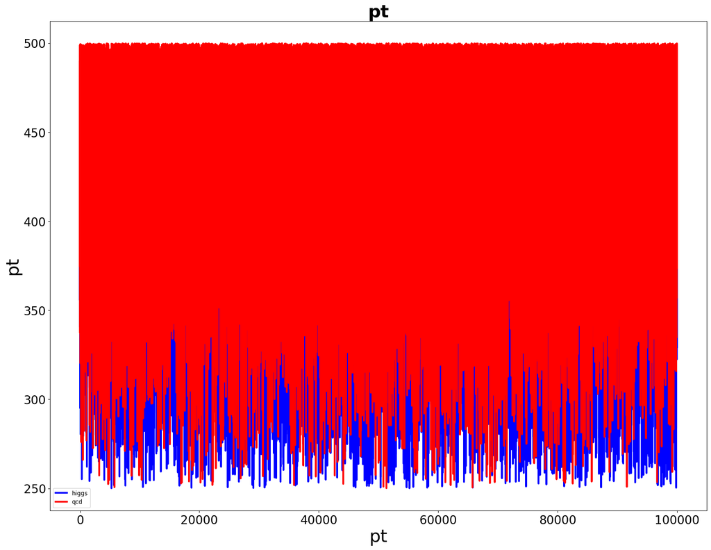

```python
X1 = higgs['pt']
X2 = qcd['pt']

fsize = 30
fig, ax = plt.subplots(1, 1)
plt.tick_params(labelsize = 20)
ax.plot(X1, c='b', label = 'higgs', linewidth = 3)
ax.plot(X2, c='r', label = 'qcd', linewidth = 3)
ax.set_xlabel(f'{X1.name}', fontsize = fsize)
ax.set_ylabel(f'{X2.name}', fontsize = fsize)
ax.set_title(f'{X2.name}', fontsize = fsize, fontweight = 'bold')
ax.legend()
plt.show()
```

Clearly, we need to bin our data to make some sense of it.

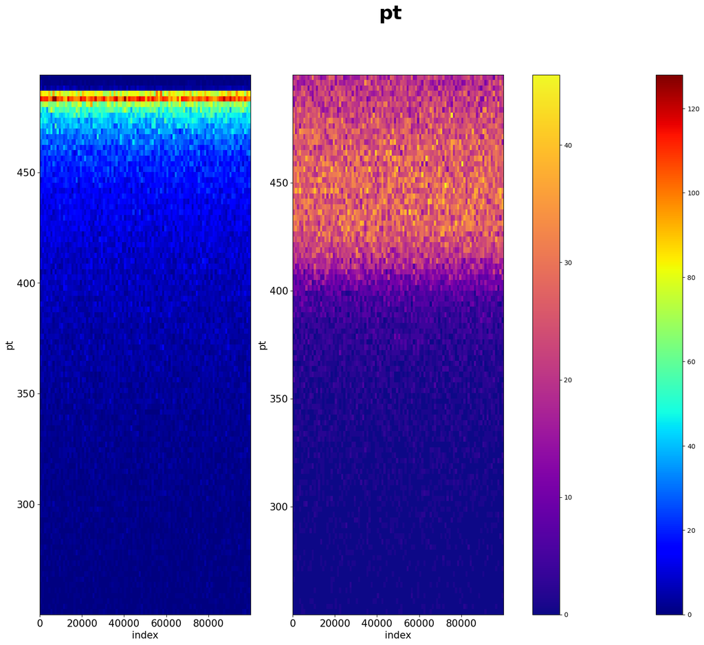

```python
bins = 100

fig, ax = plt.subplots(1, 2)
fig.suptitle(f'{X1.name}', fontsize = fsize, fontweight = 'bold')

ax[0].tick_params(labelsize = 15)
ax[1].tick_params(labelsize = 15)
h1 = ax[0].hist2d(X1.index, X1, bins, linewidth = 3, cmap='jet')
h2 = ax[1].hist2d(X2.index, X2, bins, linewidth = 3, cmap='plasma')
ax[0].set_xlabel('index', fontsize = 15)
ax[0].set_ylabel('pt', fontsize = 15)
ax[1].set_xlabel('index', fontsize = 15)
ax[1].set_ylabel('pt', fontsize = 15)
fig.colorbar(h1[3], ax=ax)
fig.colorbar(h2[3], ax=ax)
plt.show()
```

We might as well create a loop plotting each Higgs data column and compare it to its counterpart in the QCD dataset.

```python
higgs.columns
```

```
Index(['pt', 'eta', 'phi', 'mass', 'ee2', 'ee3', 'd2', 'angularity', 't1',
       't2', 't3', 't21', 't32', 'KtDeltaR'],
      dtype='object')
```

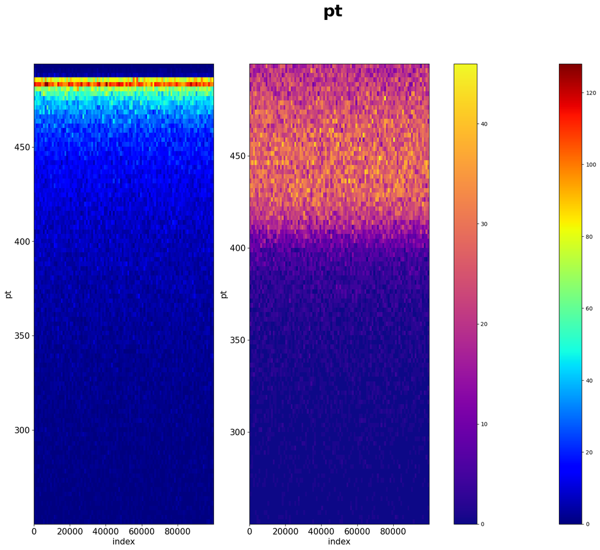

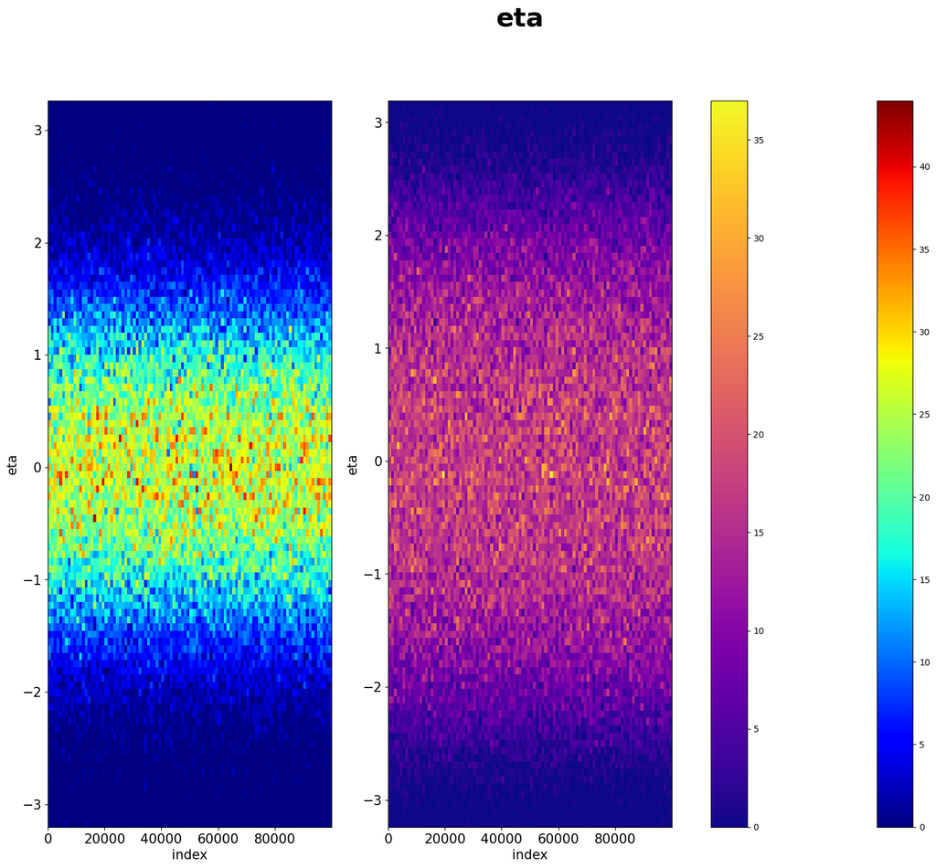

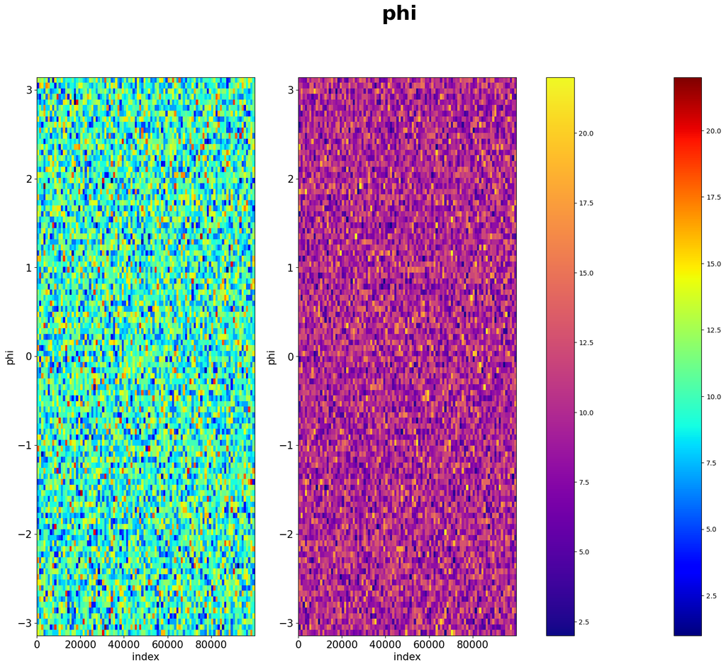

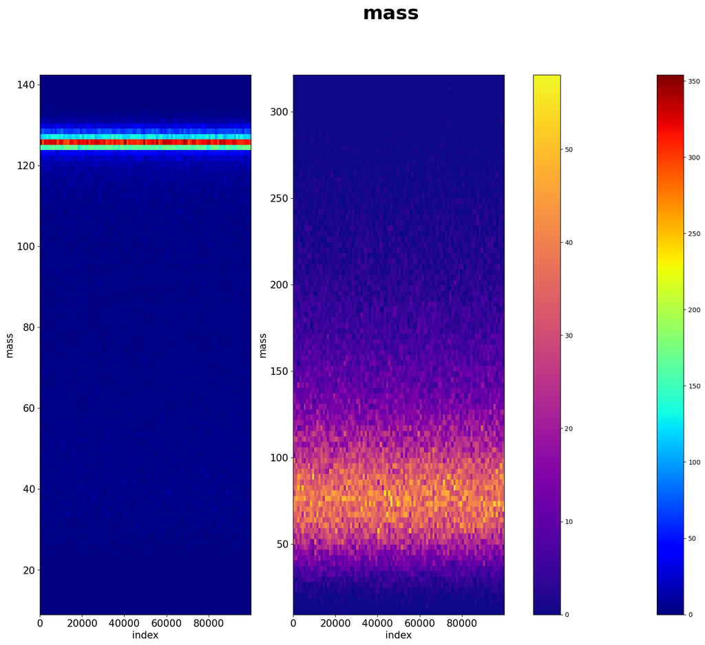

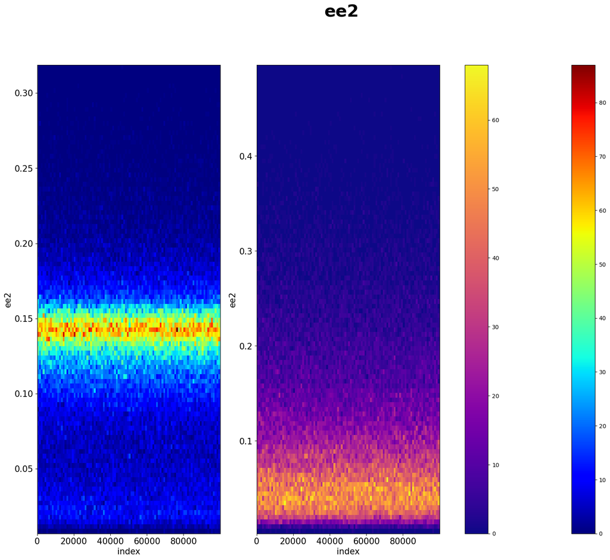

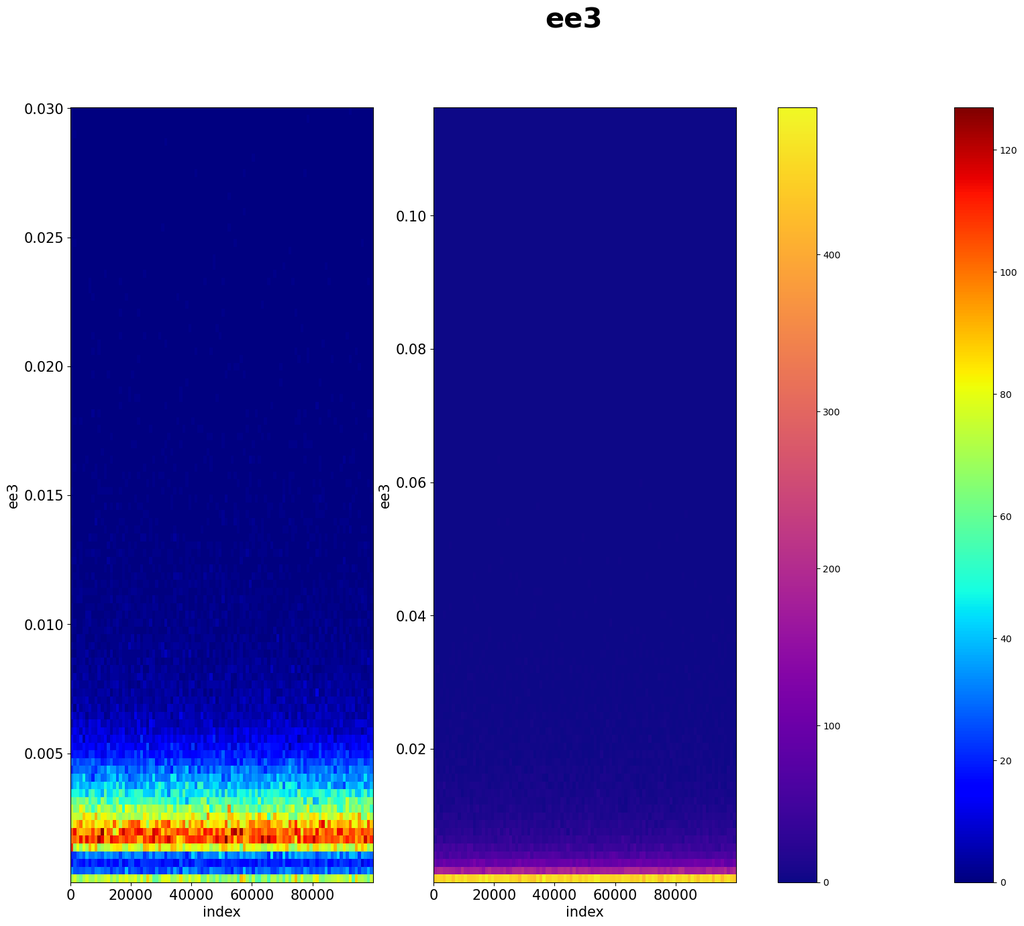

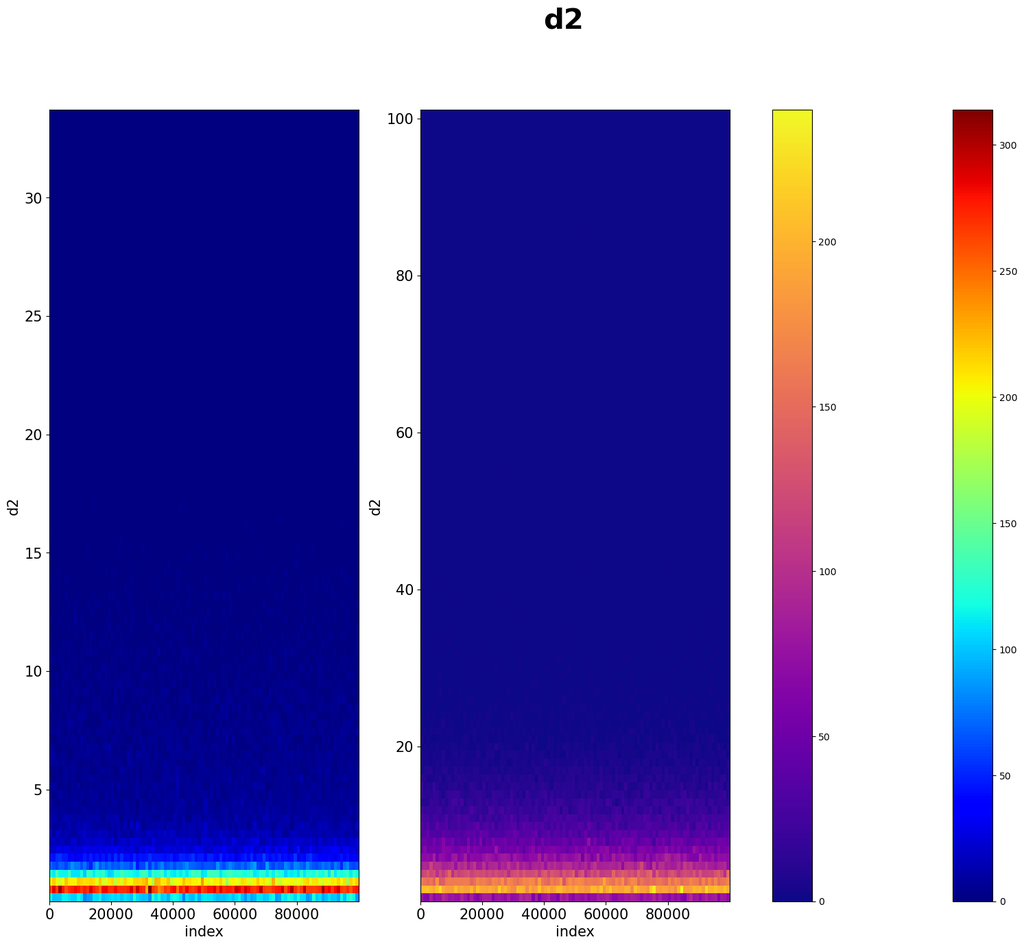

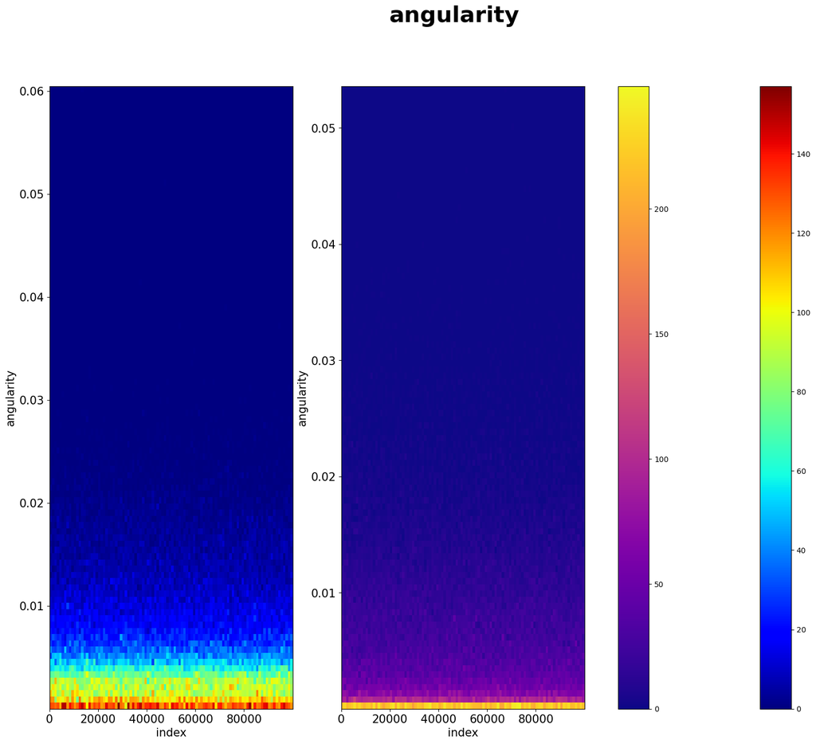

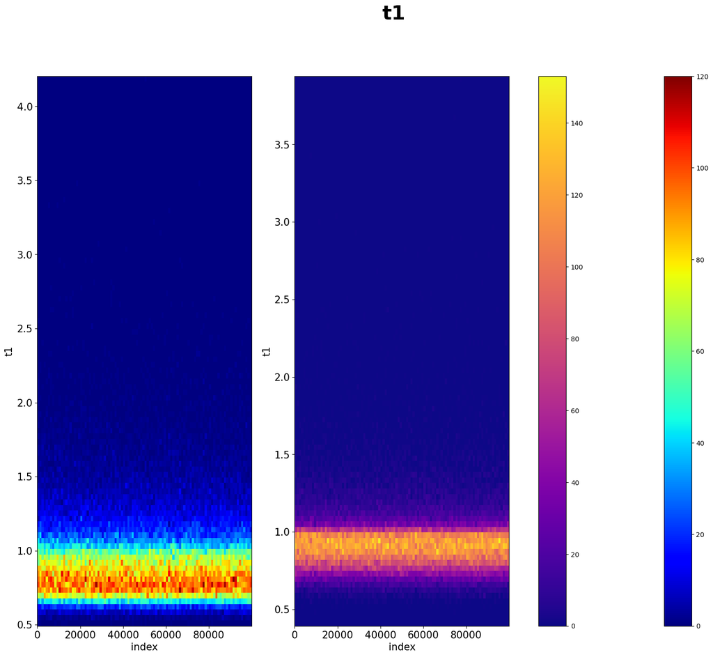

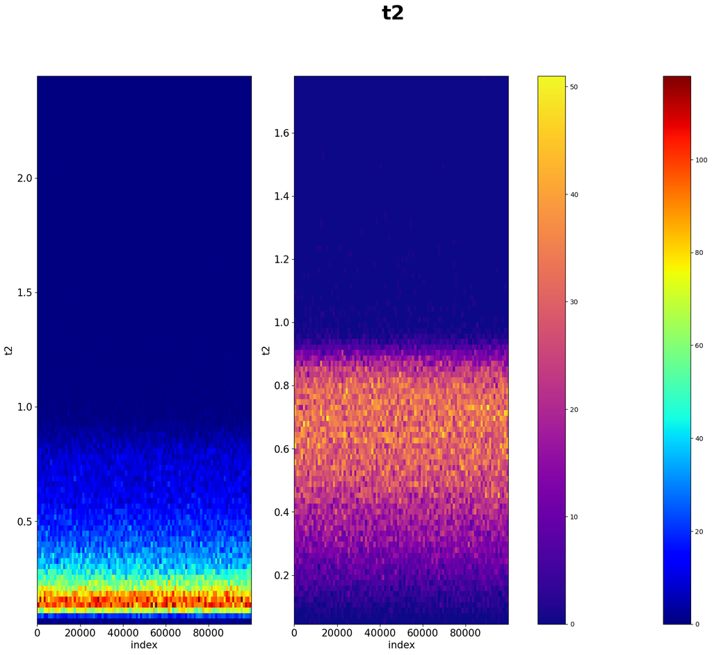

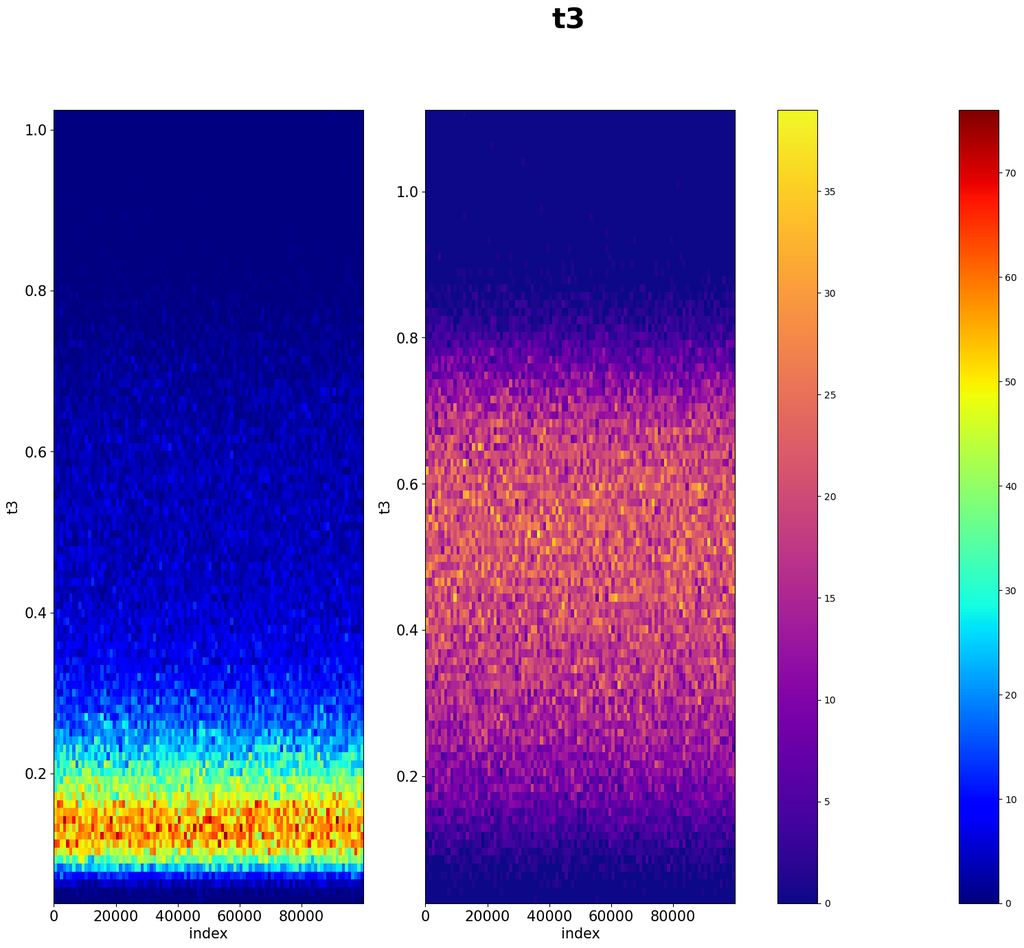

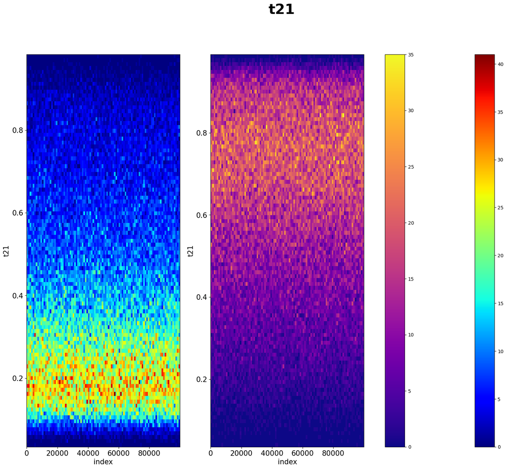

[2 more figures not shown]

```python
for name in higgs.columns:
    X1 = higgs[f'{name}']
    X2 = qcd[f'{name}']

    bins = 100

    fig, ax = plt.subplots(1, 2)
    fig.suptitle(f'{X1.name}', fontsize = fsize, fontweight = 'bold')

    ax[0].tick_params(labelsize = 15)
    ax[1].tick_params(labelsize = 15)
    h1 = ax[0].hist2d(X1.index, X1, bins, linewidth = 3, cmap='jet')
    h2 = ax[1].hist2d(X2.index, X2, bins, linewidth = 3, cmap='plasma')
    ax[0].set_xlabel(f'index', fontsize = 15)
    ax[0].set_ylabel(f'{name}', fontsize = 15)
    ax[1].set_xlabel(f'index', fontsize = 15)
    ax[1].set_ylabel(f'{name}', fontsize = 15)
    fig.colorbar(h1[3], ax=ax)
    fig.colorbar(h2[3], ax=ax)
    plt.show()
```

Let's do the same thing but plot each data column against its $p_T$.

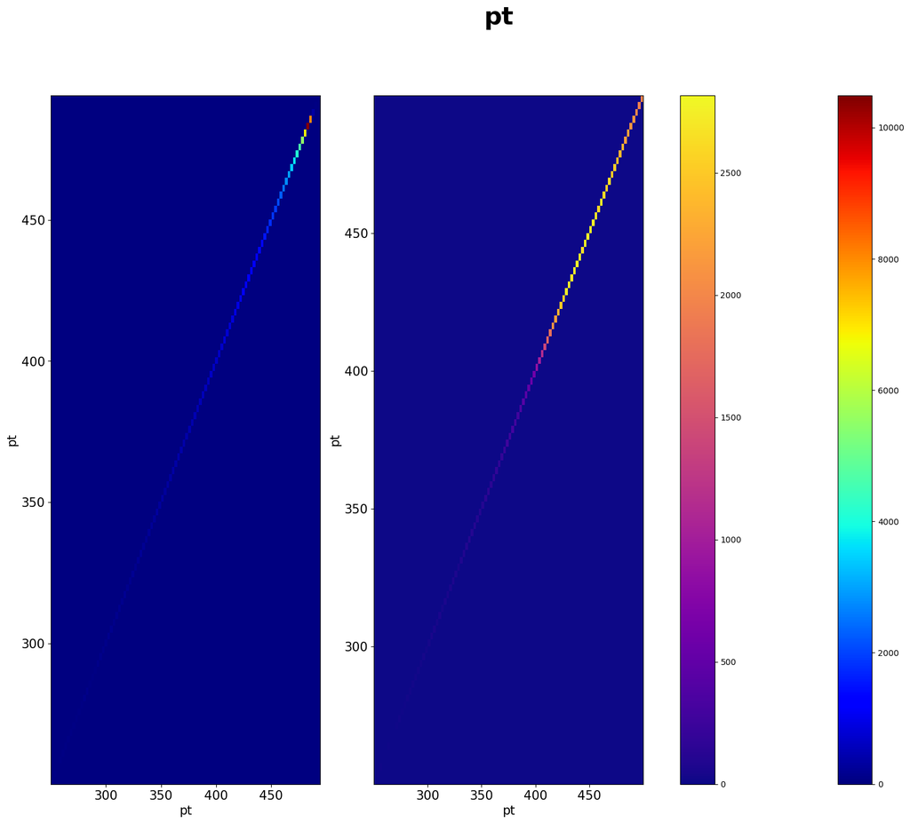

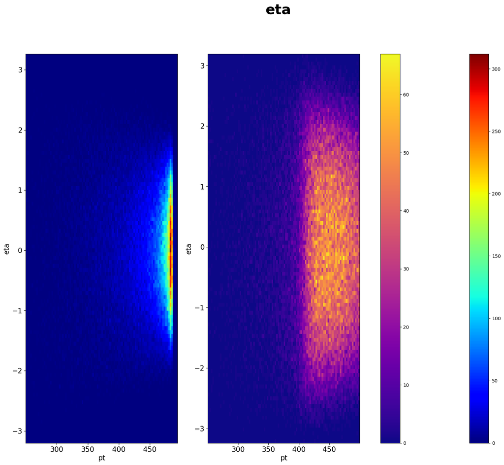

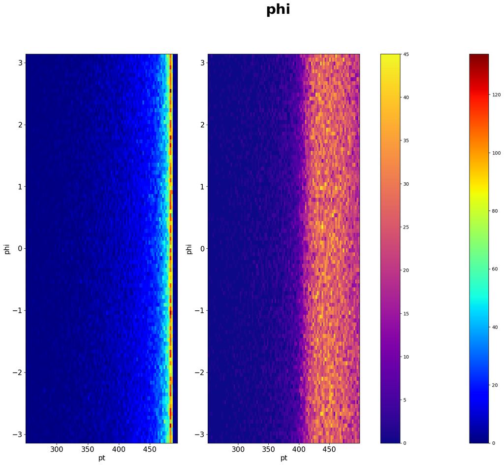

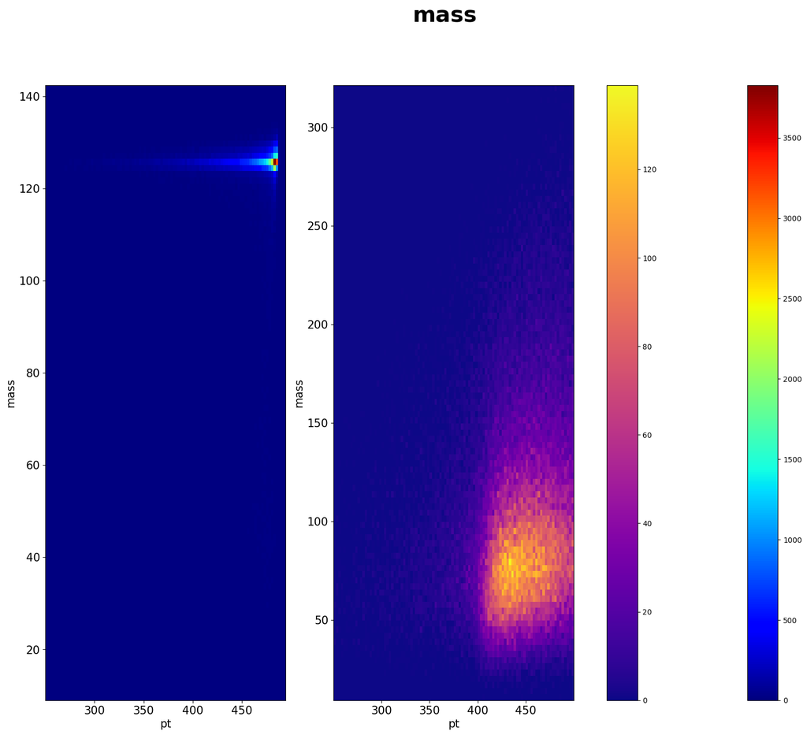

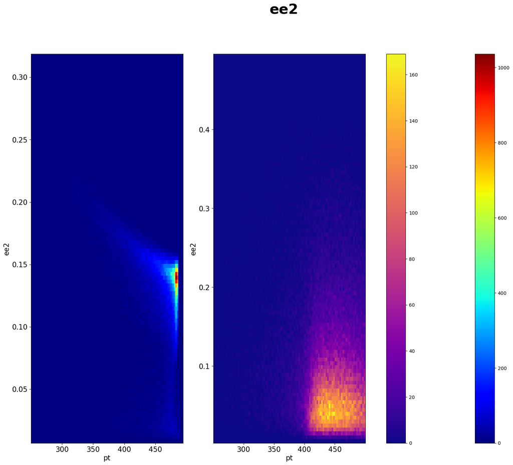

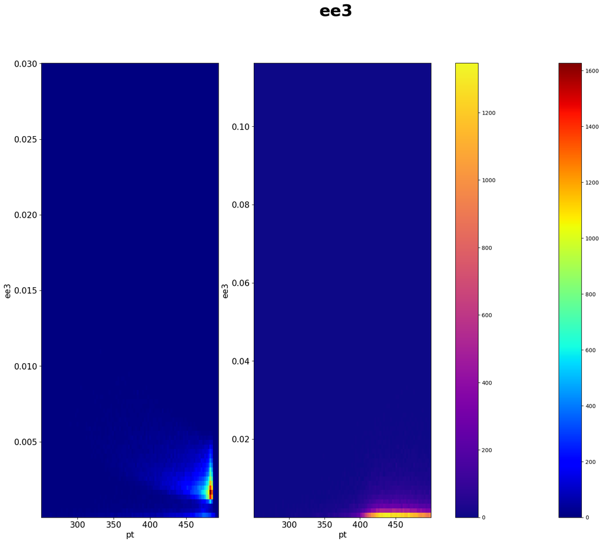

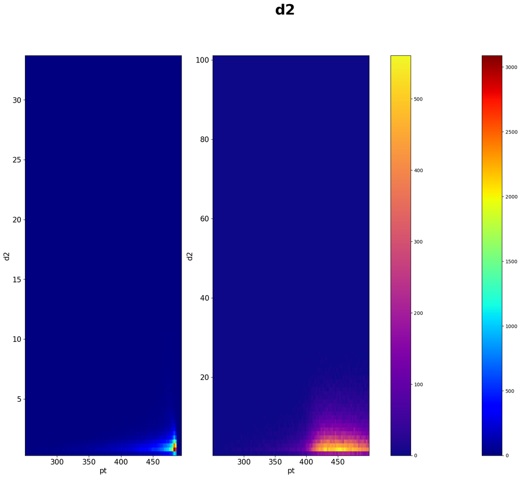

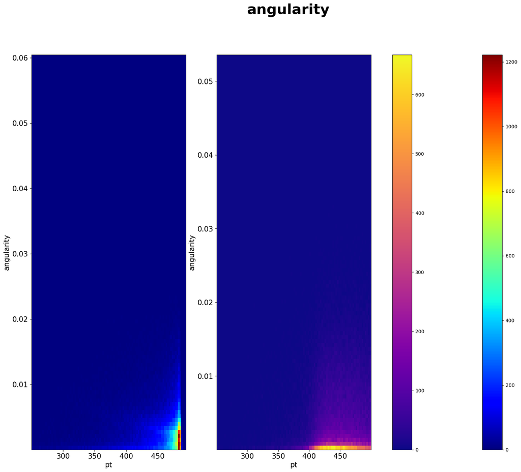

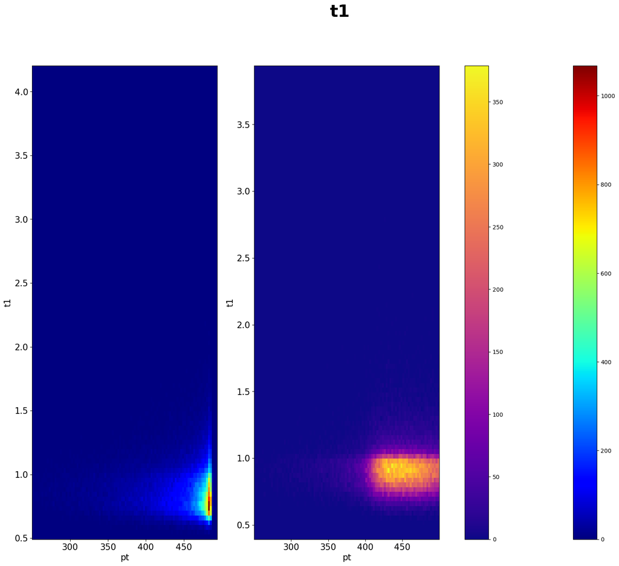

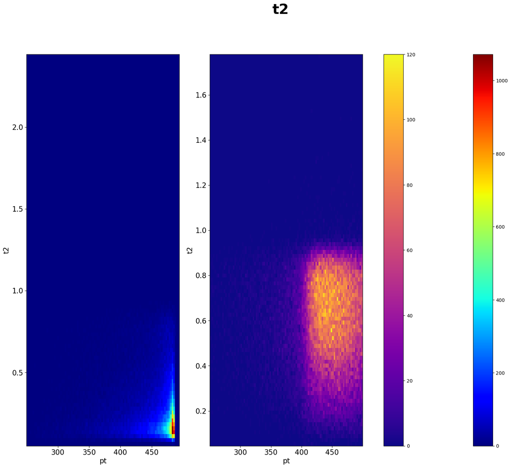

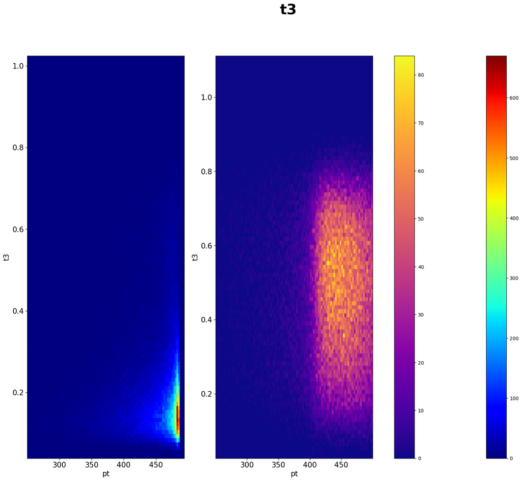

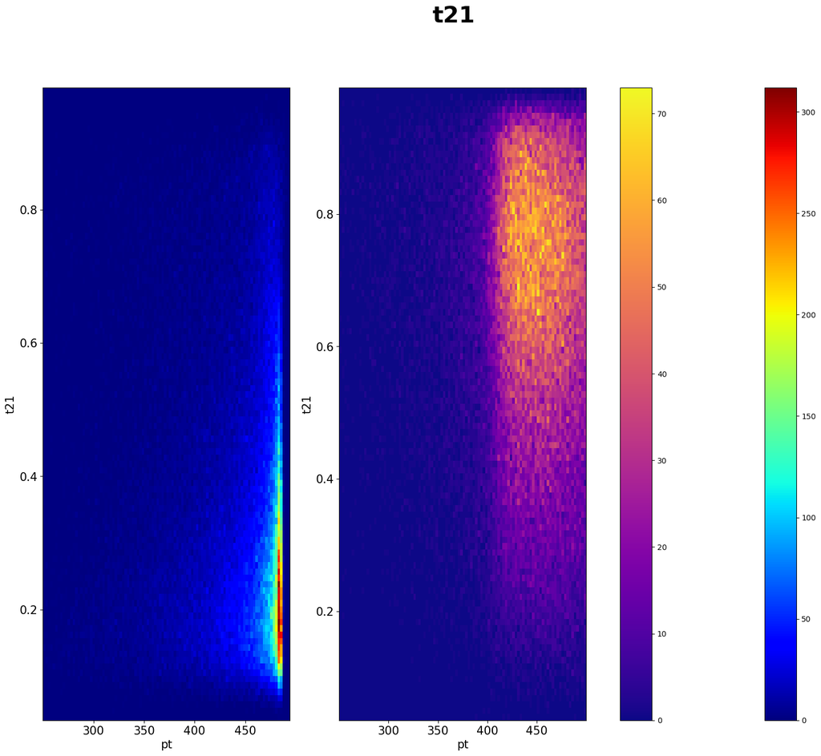

[2 more figures not shown]

```python
for name in qcd.columns:
    X1 = higgs[f'{name}']
    X2 = qcd[f'{name}']

    bins = 100

    fig, ax = plt.subplots(1, 2)
    fig.suptitle(f'{X1.name}', fontsize = fsize, fontweight = 'bold')

    ax[0].tick_params(labelsize = 15)
    ax[1].tick_params(labelsize = 15)
    h1 = ax[0].hist2d(higgs.pt, X1, bins, linewidth = 3, cmap='jet')
    h2 = ax[1].hist2d(qcd.pt, X2, bins, linewidth = 3, cmap='plasma')
    ax[0].set_xlabel(f'pt', fontsize = 15)
    ax[0].set_ylabel(f'{name}', fontsize = 15)
    ax[1].set_xlabel(f'pt', fontsize = 15)
    ax[1].set_ylabel(f'{name}', fontsize = 15)
    fig.colorbar(h1[3], ax=ax)
    fig.colorbar(h2[3], ax=ax)
    plt.show()
```

We don't really have to plot 2D histograms to represent the data, so we can plot the data in the following way.

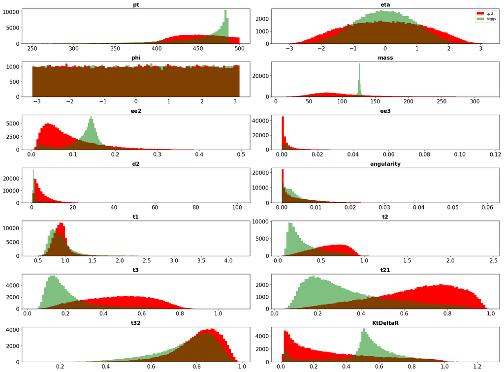

```python
fig, ax = plt.subplots(7, 2)
fig.tight_layout(pad=3.0)

for i in range(0,qcd.columns.size):
    name = qcd.columns[i]
    X1 = qcd[f'{name}']
    X2 = higgs[f'{name}']

    bins = 100

    row = math.floor(i/2)
    col = i%2

    ax[row, col].tick_params(labelsize = 15)
    ax[row, col].tick_params(labelsize = 15)
    ax[row, col].hist(X1, bins, color='r', linewidth = 3, label = 'qcd')
    ax[row, col].hist(X2, bins, color='g', alpha = 0.5, linewidth = 3, label='higgs')
    ax[row, col].set_title(f'{name}', fontsize = 15, fontweight='bold')
ax[0, 1].legend();
```

- **pt** - We have already described **$p_T$** above, but as a reminder, this is the transverse momentum - the momentum perpendicular to the colliding particle beams - of the jet.
- **phi** - the azimuthal angle about the axis of the colliding beams at which the detector detects the outcoming jets. The angle is seemingly random and is fairly evenly distributed across the values $-\pi<\phi<\pi$. Adding up all the collision counts across this space should yield the number of jets which is 100,000 as previously stated (this should be true for all other frames plotted above).
- **'eta'** - is described as the *pseudorapidity* which is related to and depends on *theta* - the angle of the jet relative to the colliding beams. Thus, since the space in *eta* spans from negative infinity to infinity it makes sense that the distribution is a Gaussian centered on zero, as this will be the most probably value of *eta*. An *eta* of 0 corresponds to a jet with a completely perpendicular angle from the colliding beams (90 degrees) while an *eta* of specifically 1 and -1 corresponds to an angle of 40 and 130 degrees relative to the beam. Hence, *eta* of $\infty$ and $-\infty$ corresponds to jets parallel and antiparallel respectively to the beam. Hence, $-\infty < \eta < \infty$ corresponds to $-\pi < \theta < \pi$.
- **angularity** - a family of infrared-safe quantities that have characteristic distributions for two-body decays
- **mass** - given in GeV and the most probable Higgs mass is stated as 125 GeV. This will of course have some uncertainty which is reflected in the Higgs dataset's mass data. The mass of the quantum chromodynamics (QCD) background particles are more spread out as the biproducts of pp-collisions can result in a variety of particles with different masses. The mass is reconstructed from the muon-corrected combined mass of the jet.
- **ee2 and ee3** - correspond to the energy correlation functions (the i-th energy correlation function; $i=2,3$) which are based on the energies and pair-wise angles of particles within a jet
- **d2** - is a function of the energy correlation functions $ECF_3 ·(\frac{ECF_1}{ECF_2})^3$. Thus, *d2* is related to the parameters *ee2* and *ee3*.
- **t1**, **t2**, **t3**, **t21** and **t32** - these are the $\tau$-parameters which gives the n-subjettiness of the jet. N-subjettiness sums the angular distances of jet constituents to their nearest subjet axis
- **KtDeltaR** - $\Delta R$ of two subjets within the large-$R$ jet. This corresponds to the minimal relative transverse momentum between particles.

For more information on the jet parameters, see p. 17 in this paper https://arxiv.org/pdf/1906.11005v2.pdf.

## Correlations between features (not already previously mentioned)

Several of these properties are related to each other.

*ee2* and *ee3* have similar shapes since these are both functions of the same type (energy correlation functions), and we plot them again with a smaller bin size to emphasize this.

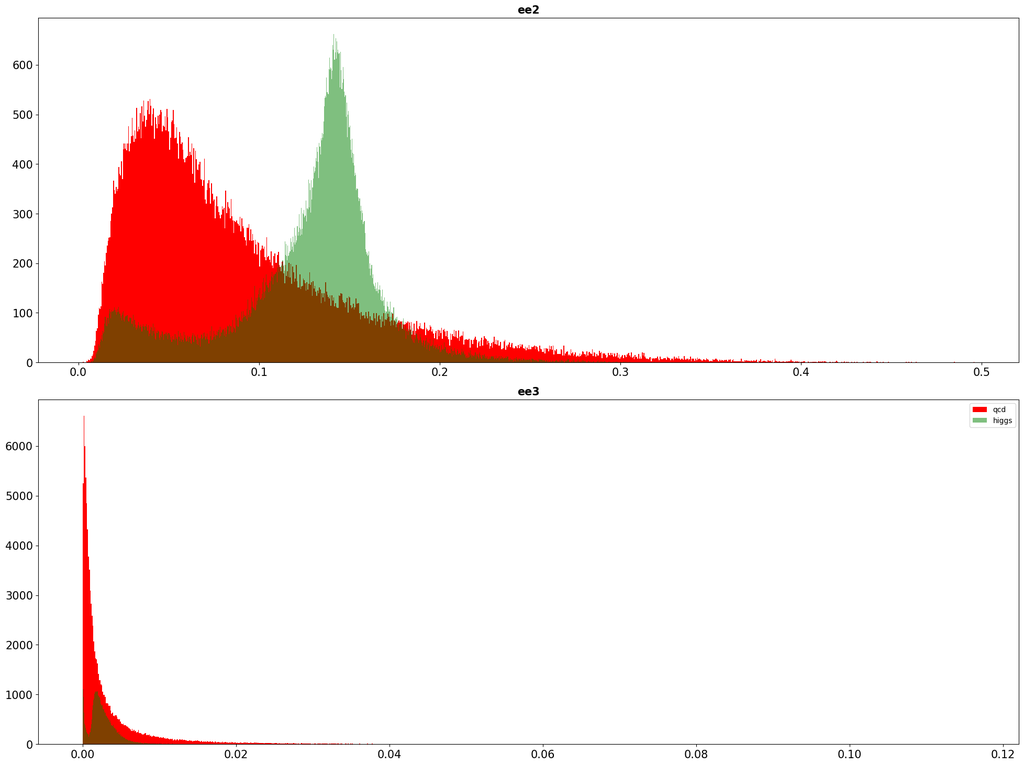

```python
fig, ax = plt.subplots(2, 1)
fig.tight_layout(pad=3.0)

name = 'ee2'
X1 = qcd[f'{name}']
X2 = higgs[f'{name}']

bins = 1000

i = 0
ax[i].tick_params(labelsize = 15)
ax[i].tick_params(labelsize = 15)
ax[i].hist(X1, bins, color='r', linewidth = 3, label = 'qcd')
ax[i].hist(X2, bins, color='g', alpha = 0.5, linewidth = 3, label='higgs')
ax[i].set_title(f'{name}', fontsize = 15, fontweight='bold')

name = 'ee3'
X1 = qcd[f'{name}']
X2 = higgs[f'{name}']

i = 1
ax[i].tick_params(labelsize = 15)
ax[i].tick_params(labelsize = 15)
ax[i].hist(X1, bins, color='r', linewidth = 3, label = 'qcd')
ax[i].hist(X2, bins, color='g', alpha = 0.5, linewidth = 3, label='higgs')
ax[i].set_title(f'{name}', fontsize = 15, fontweight='bold')
ax[1].legend();
```

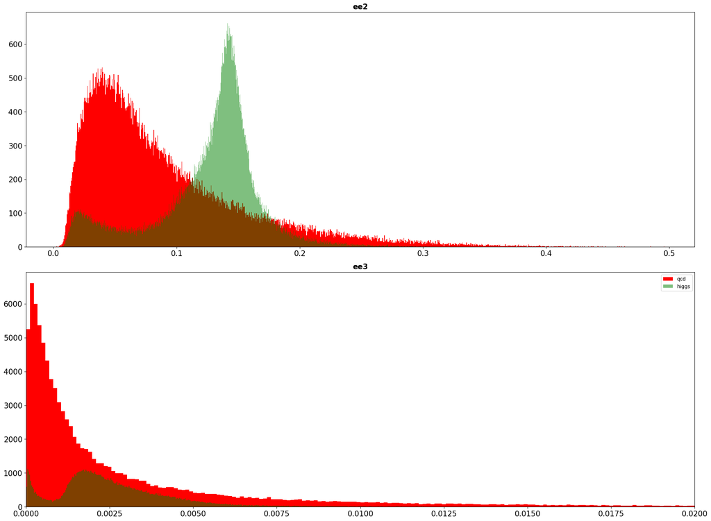

```python
# Limiting x-axis

fig, ax = plt.subplots(2, 1)
fig.tight_layout(pad=3.0)

name = 'ee2'
X1 = qcd[f'{name}']
X2 = higgs[f'{name}']

bins = 1000

i = 0
ax[i].tick_params(labelsize = 15)
ax[i].tick_params(labelsize = 15)
ax[i].hist(X1, bins, color='r', linewidth = 3, label = 'qcd')
ax[i].hist(X2, bins, color='g', alpha = 0.5, linewidth = 3, label='higgs')
ax[i].set_title(f'{name}', fontsize = 15, fontweight='bold')

name = 'ee3'
X1 = qcd[f'{name}']
X2 = higgs[f'{name}']

i = 1
ax[i].tick_params(labelsize = 15)
ax[i].tick_params(labelsize = 15)
ax[i].hist(X1, bins, color='r', linewidth = 3, label = 'qcd')
ax[i].hist(X2, bins, color='g', alpha = 0.5, linewidth = 3, label='higgs')
ax[i].set_title(f'{name}', fontsize = 15, fontweight='bold')
ax[i].set_xlim([0, 0.02])
ax[1].legend();
```

## Computing Expected Discovery Sensitivity

**Normalize each dataset and compute the expected discovery sensitivity!**

From the description of the datasets, we know that:

$N_{Higgs} = 100$

$N_{QCD} = 20\,000$

Since we expect the background to yield 20,000 events, then we can define our background as a Poisson distribution with a mean of 20,000.

```python
mean_qcd = 20_000
qcd = stats.poisson(mu=mean_qcd)
```

Then, if we measure 100 Higgs events, we would measure 20,100 events in this background. We can calculate the discovery sensitivity below.

```python
Y = 20_100

prob = qcd.sf(Y)
sigma = abs(stats.norm.ppf(prob))
prob, sigma
```

```
(0.23847212190687442, 0.7112259282313185)
```

```python
print(f'The discovery sensitivity for observing 100 Higgs events is {sigma:.2f} sigma corresponding to a probability of {prob:.2f}.')
```

```
The discovery sensitivity for observing 100 Higgs events is 0.71 sigma corresponding to a probability of 0.24.
```

## Selection Plan

In order to detect a Higgs boson with some degree of confidence, we need to establish certain selection criteria for the experimental analysis that will be done in order to increase our discovery sensitivity and discover the Higgs boson.

Since the pseudorapidity *eta* is related to how perpendicular the jet is relative to the beam and thus how much the jet is independent of the incidents beams (only contains momentum of particles created in the collision) - this is a natural selection criteria. Therefore, we should plan to select Higgs jets with *eta* close to 0. The most transverse jets are the ones we are interested in.

Moreover, another selection criteria for our experiment must be some sort of high $p_T$. This is because the jet must contain at least some threshold of created particles and thus transverse momentum. We need a **high p_T**.

We should also look for properties in the data that are noticeably different for the Higgs boson when compared to the background. By examining our previous plots, we see that this is the case for especially **ee2, mass, t2, t3, t21 and KtDeltaR**. Hence, we need to pay special attention to discrepancies in the data for these variables to search for the Higgs boson.